# **Panorama da inflação**

# IPCA

|  | 08/2007 | 07/2008 | 08/2008 |
| --- | --- | --- | --- |
| Variação mensal | 0.47% | 0.53% | 0.28% |
| Variação acumulada no ano | 2.8% | 4.19% | 4.48% |
| Variação acumulada em 12 meses | 4.18% | 6.37% | 6.17% |

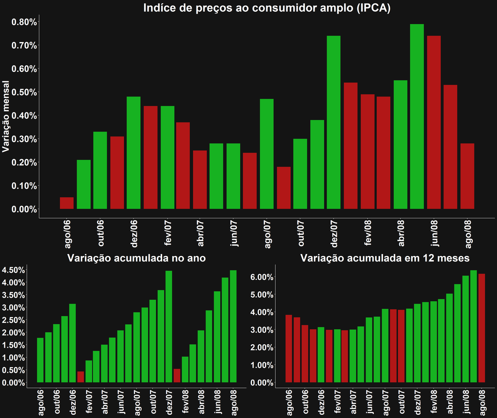

|  | Variação mensal | Variação acumulada no ano | Peso mensal |
| --- | --- | --- | --- |
| Alimentação e bebidas | -0.18% | 9.59% | 22.88% |
| Habitação | 0.77% | 3.19% | 13.03% |
| Artigos de residência | 0.23% | 0.57% | 4.25% |
| Vestuário | 0.39% | 3.46% | 6.47% |
| Transportes | 0.06% | 1.96% | 19.92% |
| Saúde e cuidados pessoais | 0.32% | 4.29% | 10.74% |
| Despesas pessoais | 0.73% | 4.64% | 9.7% |
| Educação | 0.42% | 4.48% | 7.02% |
| Comunicação | 0.69% | 1.61% | 5.99% |

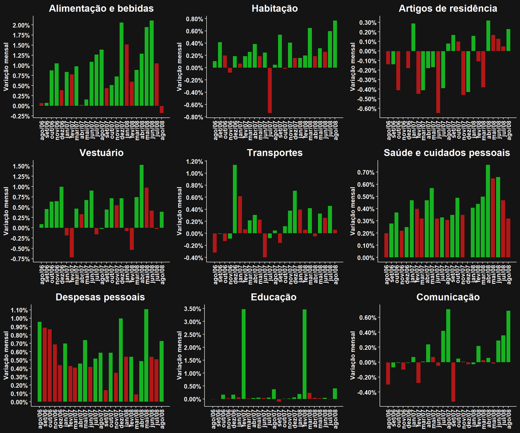

A nível de sub-itens os que mais influenciaram positivamente no resultado em relação ao seu peso foram Telefone fixo (2.27%%) e Energia elétrica residencial (1.03%%), e negativamente Tomate (-36.91%%) e Telefone celular (-2.54%%).

|  | Variação mensal | Variação acumulada no ano | Peso mensal |
| --- | --- | --- | --- |
| Telefone fixo | 2.27% | 3.26% | 3.44% |
| Taxa de água e esgoto | 1.57% | 5.26% | 1.6% |
| Energia elétrica residencial | 1.03% | 0.83% | 3.28% |
| Refeição | 0.78% | 10.71% | 4.03% |

|  | Variação mensal | Variação acumulada no ano | Peso mensal |
| --- | --- | --- | --- |
| Telefone celular | -2.54% | -1.79% | 1.43% |
| Leite pasteurizado | -2.85% | 6.23% | 1.07% |
| Tomate | -36.91% | 43.97% | 0.26% |
| Feijão - carioca (rajado)) | -5.9% | -1.15% | 0.38% |

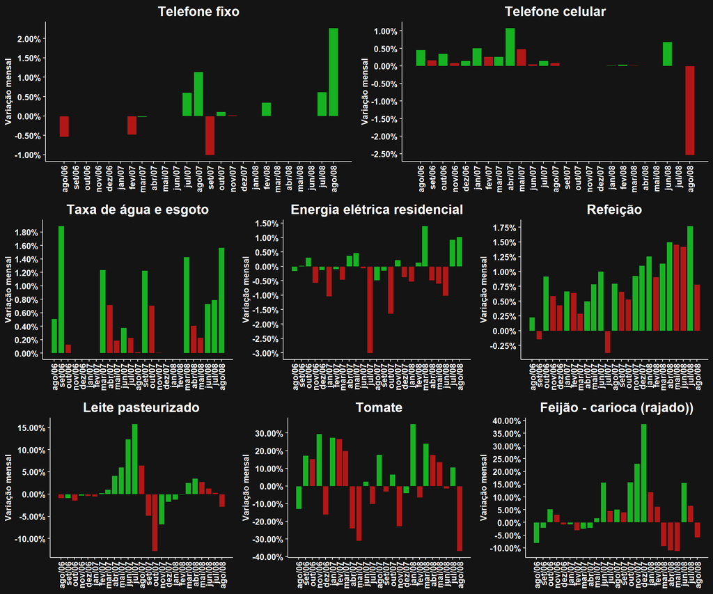

# INPC

|  | 08/2007 | 07/2008 | 08/2008 |
| --- | --- | --- | --- |
| Variação mensal | 0.59% | 0.58% | 0.21% |
| Variação acumulada no ano | 3.13% | 4.87% | 5.09% |
| Variação acumulada em 12 meses | 4.82% | 7.56% | 7.15% |

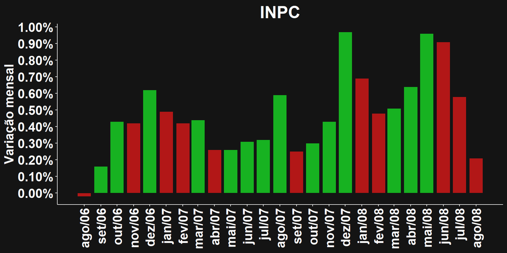

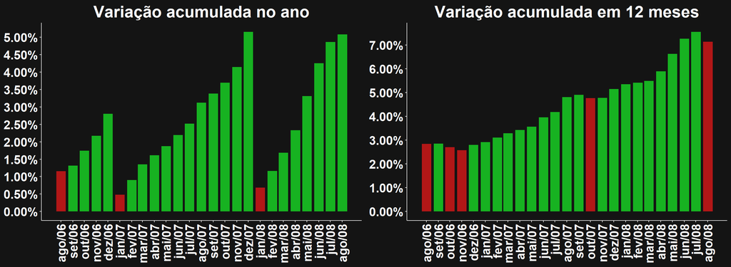

# IGP-M

O Indíce Geral de Preços de Mercado (IGP-M) variou -0.32% em agosto, valor inferior ao mesmo período do ano anterior quando apresentou uma taxa de 0.98%. Com esse resultado o indíce acumula no ano uma variação positiva de 7.19%, e em 12 meses uma variação positiva de 13.63%.

|  | 08/2007 | 07/2008 | 08/2008 |
| --- | --- | --- | --- |
| Variação mensal | 0.98% | 1.76% | -0.32% |
| Variação acumulada no ano | 2.23% | 7.53% | 7.19% |
| Variação acumulada em 12 meses | 4.63% | 15.12% | 13.63% |

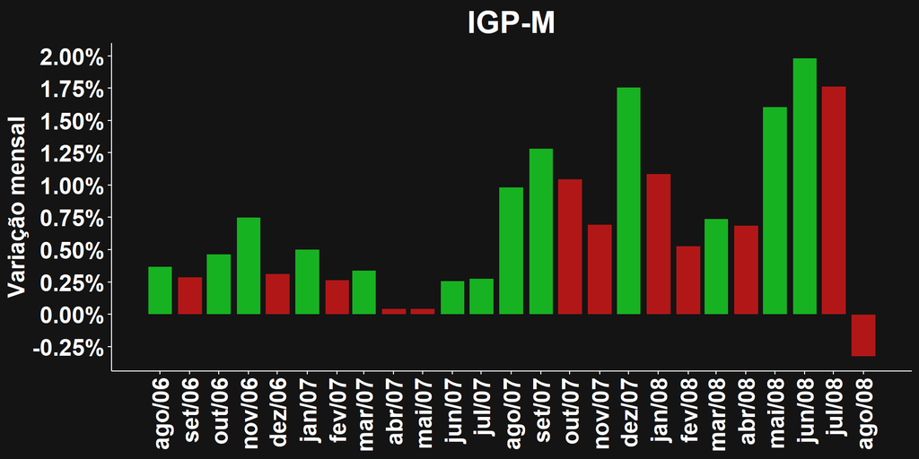

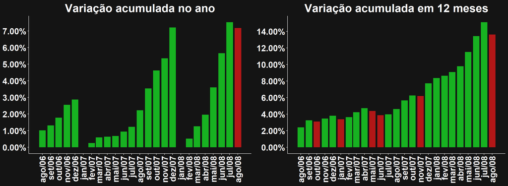